# Workshop 2 - [Week 5] comparing means - solutions

Notebook code chunks can be inserted quickly using the keyboard shortcut Ctrl + Alt + I (macOS: Cmd + Option + I ), or via the Insert menu in the editor toolbar.

CLASS EXERCISE NOTE: this is free text so you do not need to use a # tag. Unless you are putting notes in the code windows [see below]

Load the libraries we might need [NOTE: may need to install these. Check the packages list in the bottom right pane of the RStudio window]

```r
library(tidyverse) # has library dplyr in in
library(ggfortify) # has the autoplot function for creating the validation plots
library(car) # for kruskal-Wallis test
library(coin) # for the Wilcox non-parametric test
```

When you attempt to save R might ask for an undated version of R markdowm. That’s fine, say “yes”.

Do the following for all three data files: 1. load in the data and examine it’s structure (including experimental balance) 2. Posit your hypotheses (null and alternative) 3. play with some pictures 4. draw a contingency table to figure out how the data are structured 5. Select an appropriate model 6. Validate the model 7. Briefly interpret the results - in your script file!!!!

## EXERCISE 1

Filename: Hoglouse.csv - a file of water louse distribution along a rivers in Devon response - hoglouse numbers/abundance explanatory variable - Upper, Mid and lower sites (i.e. longitudinal profile) see Gardner’s book….on the reading lists —————————————————————————————-

```r
Hog <- read.csv("Hoglouse.csv", header=TRUE)
```

Look at its structure

```r
glimpse(Hog) #in the dplyr library
```

```
Rows: 17
Columns: 2
$ Count <int> 3, 4, 5, 9, 8, 10, 9, 11, 12, 9, 10, 11, 4, 3, 7, 9, 11
$ Site  <fct> Upper, Upper, Upper, Upper, Upper, Upper, Upper, Mid, Mid, Mid, Mid, Mid, Lower, Lower, Lower, Lowe…
```

```r
str(Hog)
```

```
'data.frame':   17 obs. of  2 variables:
 $ Count: int  3 4 5 9 8 10 9 11 12 9 ...
 $ Site : Factor w/ 3 levels "Lower","Mid",..: 3 3 3 3 3 3 3 2 2 2 ...
```

```r
View(Hog)
```

```r
Hog$FSite <- as.factor(Hog$Site)
```

Make a picture - to look at the structure

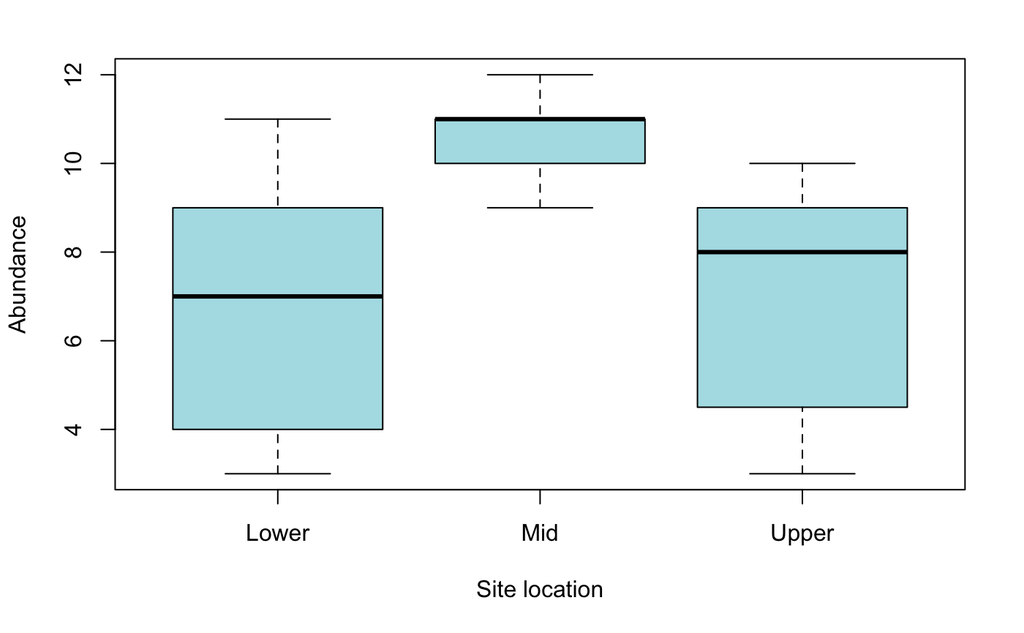

```r
boxplot(Hog$Count ~ Hog$ Site, col = "powderblue", xlab="Site location", ylab = "Abundance") # Not symetrical so not normally distributed
```

Repeated with the ggplot2. As I have said numerous time, what you use to plot i.e. base R or ggplot2 is up to you.

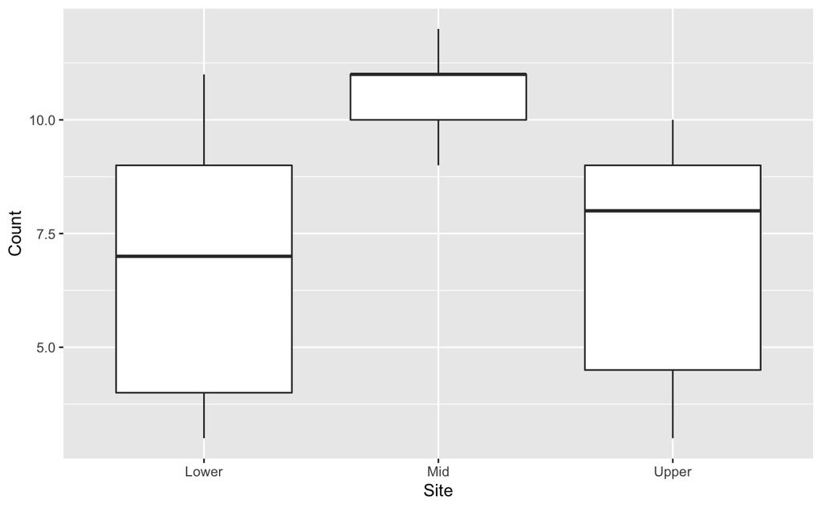

```r
ggplot(Hog, aes(Site, Count)) + geom_boxplot() #+ xlab("Site location") + ylab("Abundance"))
```

Check normality with histogram and QQ-plot

[figure not shown]

```r
par(mfrow = c(2, 1))
hist(Hog$Count, main = "", col = "red", xlab = "Count")
qqnorm(Hog$Count); qqline(Hog$Count)
```

Doesn’t look promising for normality - check with shapiro-Wilkes test

```r
shapiro.test(Hog$Count)
```

```
    Shapiro-Wilk normality test

data:  Hog$Count
W = 0.88833, p-value = 0.04349
```

Nope - not normally distributed. What about heterogeneity of variances….?

```r
leveneTest(Hog$Count, Hog$Site) # looks fine
```

```
Levene's Test for Homogeneity of Variance (center = median)
      Df F value Pr(>F)
group  2   1.992 0.1733
      14
```

```r
Upper <- subset(Hog, Site == "Upper")
Mid <- subset(Hog, Site == "Mid")
Lower <- subset(Hog, Site == "Lower")
var(Upper$Count)
```

```
[1] 7.809524
```

```r
var(Mid$Count)
```

```
[1] 1.3
```

```r
var(Lower$Count)
```

```
[1] 11.2
```

We conclude the data are not normally distributed with homogeneity of variance marginal = needs a non-parametric test

```r
kruskal.test(Hog$Count ~ Hog$Site)
```

```
    Kruskal-Wallis rank sum test

data:  Hog$Count by Hog$Site
Kruskal-Wallis chi-squared = 6.5396, df = 2, p-value = 0.03801
```

Interpretation: Big difference between the means, especially in the mid regions of the river. We can examine the differences in the individual means [someone in class asked about this - great idea!]. We do this by using Wilcox tests to compare the individual pairwise comparisons ie: Upper to Mid Mid to Lower Upper to Lower To do this we three new dataframes with the appropriate “Site” rows comparisons

```r
Upper_Mid = filter(Hog,Site %in% c("Upper","Mid")) # uses dplyr to subset using multiple criteria
Mid_Lower = filter(Hog,Site %in% c("Mid","Lower"))
Upper_Lower = filter(Hog,Site %in% c("Upper","Lower"))
```

```r
wilcox_test(Count ~ Site, data = Upper_Mid, distribution = "exact")
```

```
    Exact Wilcoxon-Mann-Whitney Test

data:  Count by Site (Mid, Upper)
Z = 2.462, p-value = 0.01263
alternative hypothesis: true mu is not equal to 0
```

```r
wilcox_test(Count ~ Site, data = Mid_Lower, distribution = "exact")
```

```
    Exact Wilcoxon-Mann-Whitney Test

data:  Count by Site (Lower, Mid)
Z = -1.9092, p-value = 0.07937
alternative hypothesis: true mu is not equal to 0
```

```r
wilcox_test(Count ~ Site, data = Upper_Lower, distribution = "exact")
```

```
    Exact Wilcoxon-Mann-Whitney Test

data:  Count by Site (Lower, Upper)
Z = -0.082065, p-value = 0.9747
alternative hypothesis: true mu is not equal to 0
```

We find: Upper to mid comparison has a sig difference p-value = 0.01263 Lower to Mid - not sig at p-value = 0.07937. Close but not below P=<0.05 Lower to Upper not sig at p-value = 0.9747. So our finding of Kruskal-Wallis chi-squared = 6.5396, df = 2, p-value = 0.03801 is being driven by one difference in the paired means: Upper to Mid.

## EXERCISE 2

Filename: Medley.csv Medley and Clements (1998) investigated the impact of zinc contamination (and other heavy metals) on the diversity of diatom species in the USA Rocky Mountains (from Box 8.1 of Quinn and Keough (2002)) File contents: DIATOM - number of different species of diatoms on the a known area of rocks in streams (continous variable) ZINC - mpm of zinc in the water column (background, low, medium, high) (factor - explanatory variable)

```r
Algal <- read.csv("Medley.csv")
```

```r
glimpse(Algal)
```

```
Rows: 28
Columns: 2
$ ZINC      <fct> BACK, HIGH, HIGH, MED, BACK, HIGH, BACK, BACK, HIGH, MED, MED, BACK, MED, HIGH, HIGH, HIGH, LOW…
$ DIVERSITY <dbl> 2.27, 1.25, 1.15, 1.62, 1.70, 0.63, 2.05, 1.98, 1.04, 2.19, 2.10, 2.20, 2.06, 1.90, 1.88, 0.85,…
```

check it is now a factor

[output not shown]

Make some pictures - test for normality

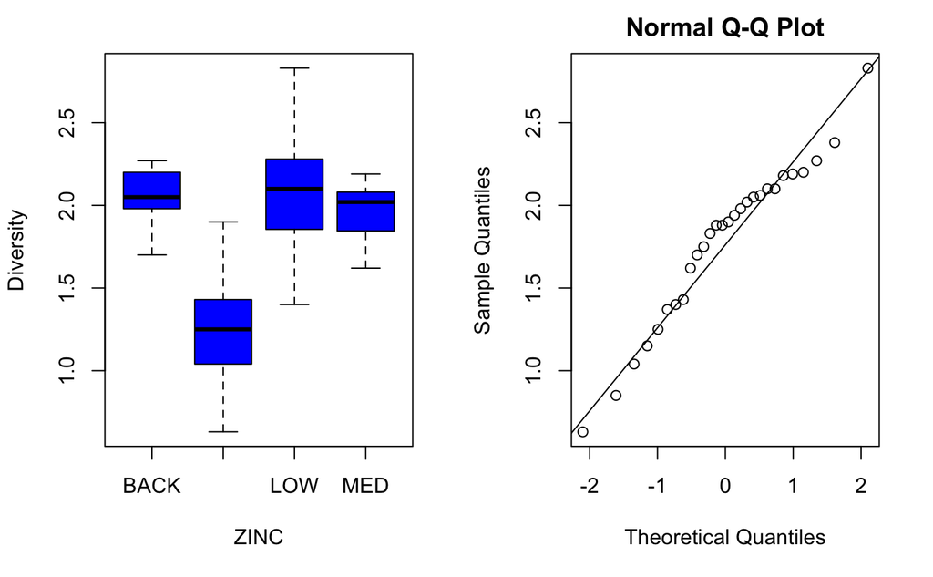

```r
par(mfrow=c(1,2))
boxplot(DIVERSITY ~ ZINC, data = Algal, col = "blue", ylab = "Diversity")
qqnorm(Algal$DIVERSITY); qqline(Algal$DIVERSITY)
```

Shapiro-wilkws test

```r
shapiro.test(Algal$DIVERSITY)
```

```
    Shapiro-Wilk normality test

data:  Algal$DIVERSITY
W = 0.95882, p-value = 0.3269
```

Looks fine /

Variances…..?

```r
leveneTest(Algal$DIVERSITY, Algal$ZINC)
```

```
Levene's Test for Homogeneity of Variance (center = median)
      Df F value Pr(>F)
group  3  1.3463 0.2829
      24
```

All good.

One-way ANOVA is appropriate do we see a difference?

```r
aov(DIVERSITY ~ ZINC, data = Algal)
```

```
Call:
   aov(formula = DIVERSITY ~ ZINC, data = Algal)

Terms:
                    ZINC Residuals
Sum of Squares  3.474202  3.129098
Deg. of Freedom        3        24

Residual standard error: 0.3610805
Estimated effects may be unbalanced
```

```r
summary(aov(DIVERSITY ~ ZINC, data = Algal)) # Note we can nest the summary command in the Anova call
```

```
            Df Sum Sq Mean Sq F value   Pr(>F)
ZINC         3  3.474  1.1581   8.882 0.000387 ***
Residuals   24  3.129  0.1304
---
Signif. codes:  0 ‘***’ 0.001 ‘**’ 0.01 ‘*’ 0.05 ‘.’ 0.1 ‘ ’ 1
```

or put into an object to use later

```r
Model <- aov(DIVERSITY ~ ZINC, data = Algal)
summary(Model)
```

```
            Df Sum Sq Mean Sq F value   Pr(>F)
ZINC         3  3.474  1.1581   8.882 0.000387 ***
Residuals   24  3.129  0.1304
---
Signif. codes:  0 ‘***’ 0.001 ‘**’ 0.01 ‘*’ 0.05 ‘.’ 0.1 ‘ ’ 1
```

Interpretation: ZINC levels impact the diversity of the diatom communities All other factors (e.g. flow, nutrient status, pH) being stable Extra bonus mark if you used a Tukey posthoc test to examine the difference between the means

```r
TukeyHSD(Model)
```

```
  Tukey multiple comparisons of means
    95% family-wise confidence level

Fit: aov(formula = DIVERSITY ~ ZINC, data = Algal)

$ZINC
                 diff        lwr        upr     p adj
HIGH-BACK -0.76222222 -1.3178090 -0.2066355 0.0046931
LOW-BACK   0.04571429 -0.5375303  0.6289589 0.9963302
MED-BACK  -0.08571429 -0.6689589  0.4975303 0.9769648
LOW-HIGH   0.80793651  0.3059595  1.3099135 0.0009302
MED-HIGH   0.67650794  0.1745309  1.1784849 0.0055192
MED-LOW   -0.13142857 -0.6638556  0.4009984 0.9033090
```

## EXERCISE 3

Filename: Quinn.csv (data from By G. P. Quinn and M. J. Keough, 2002 - “Experimental Design and Data Analysis for Biologists” ) File contents: DENSITY - Limpet density treatment (L1 = 8 individals per 225 cm2 enclosure, L2 = 15, L3 = 30 and L4 = 45) (factor - explanatory variable) SEASON - Season of the year (Spring or summer) (factor - explanatory variable) EGGS - egg production by limpets (continous response variable) —————————————————————————————

We’re going to use a two-way ANOVA to analyse this….

```r
Limpet <- read.csv("Quinn.csv")
```

check structure

```r
glimpse(Limpet)
```

```
Rows: 24
Columns: 3
$ DENSITY <fct> L1, L1, L1, L1, L1, L1, L2, L2, L2, L2, L2, L2, L3, L3, L3, L3, L3, L3, L4, L4, L4, L4, L4, L4
$ SEASON  <fct> spring, spring, spring, summer, summer, summer, spring, spring, spring, summer, summer, summer, s…
$ EGGS    <dbl> 2.875, 2.625, 1.750, 2.125, 1.500, 1.875, 2.600, 1.866, 2.066, 0.867, 0.933, 1.733, 2.230, 1.466,…
```

Change SEASON and DENSITY to factors

Plot it to see the pattern

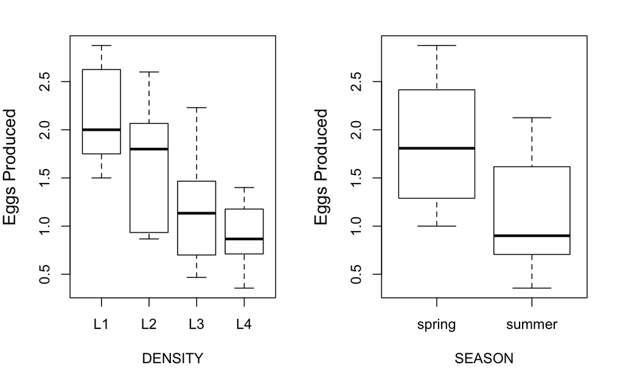

```r
par(mfrow=c(1,2))
plot(EGGS ~ DENSITY, data = Limpet, pch = 19,cex = 1.5,
     ylab = list("Eggs Produced", cex = 1.2))
plot(EGGS ~ SEASON, data = Limpet, pch = 19,cex = 1.5,
     ylab = list("Eggs Produced", cex = 1.2))
```

both indicate likely differences for each factor. Data look relatively normal

Check assumptions normality

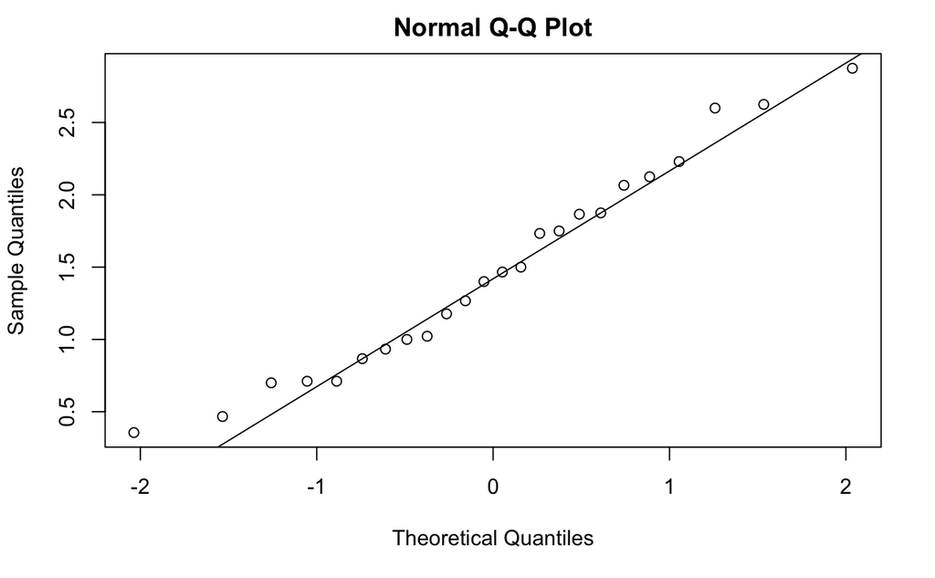

```r
qqnorm(Limpet$EGGS); qqline(Limpet$EGGS)
```

Looks fine….

```r
shapiro.test(Limpet$EGGS)
```

```
    Shapiro-Wilk normality test

data:  Limpet$EGGS
W = 0.96449, p-value = 0.5351
```

Data are normally distributed…

check for homogeneity of variance

```r
leveneTest(EGGS~DENSITY, data = Limpet)
```

```
Levene's Test for Homogeneity of Variance (center = median)
      Df F value Pr(>F)
group  3  0.4125 0.7458
      20
```

```r
leveneTest(EGGS~SEASON, data = Limpet)
```

```
Levene's Test for Homogeneity of Variance (center = median)
      Df F value Pr(>F)
group  1  0.2252 0.6398
      22
```

All fine….to do it graphically and account for both factors we need to run the model!

plot interaction

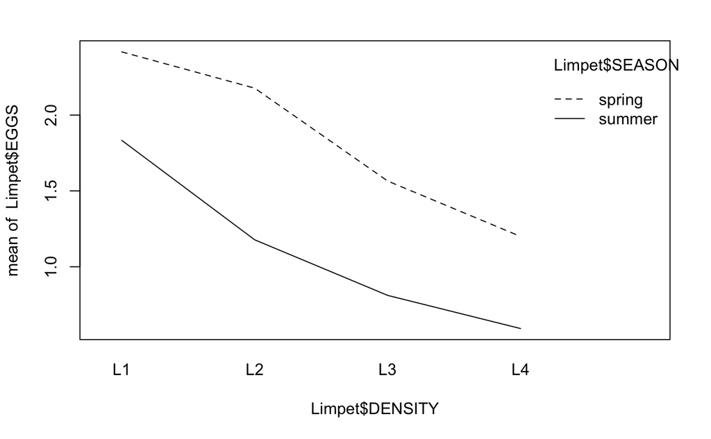

```r
interaction.plot(Limpet$DENSITY, Limpet$SEASON, Limpet$EGGS, fun = mean)
```

No indication of interactions

Run ANOVA with full interactions

```r
Limpet_aov <- aov(EGGS ~ SEASON * DENSITY, data = Limpet)
```

Look at the output

```r
summary(Limpet_aov)
```

```
               Df Sum Sq Mean Sq F value   Pr(>F)
SEASON          1  3.250   3.250  17.842 0.000645 ***
DENSITY         3  5.284   1.761   9.669 0.000704 ***
SEASON:DENSITY  3  0.165   0.055   0.301 0.823955
Residuals      16  2.915   0.182
---
Signif. codes:  0 ‘***’ 0.001 ‘**’ 0.01 ‘*’ 0.05 ‘.’ 0.1 ‘ ’ 1
```

Results indicate that SEASON and DENSITY impact egg production. There is no interaction between the two explanatory factors.

Confirm all diagnostics

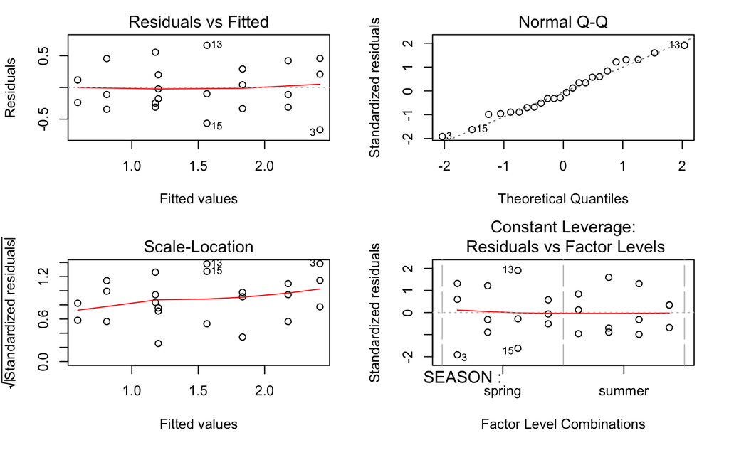

```r
par(mfrow = c(2, 2)) # set graphics device toplot four graphs in a 2 x 2 matrix
plot(Limpet_aov)
```

Or we can use the autoplot function from the ggfortify library and it does all the formatting for us! We don’t need to use the par() functions. As always - it is up to you which route you adopt or choose!

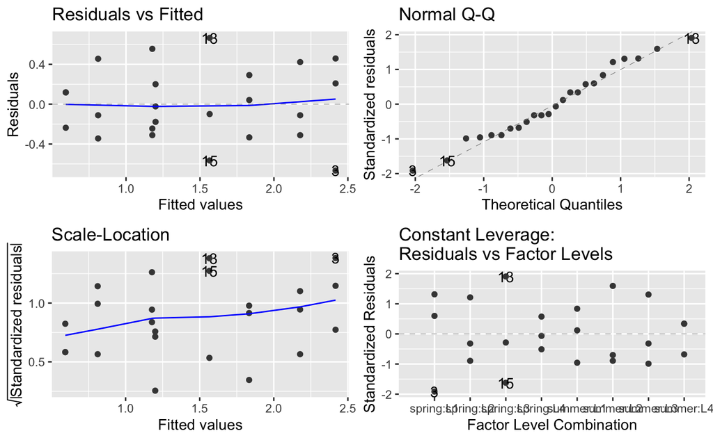

```r
autoplot(Limpet_aov) # called from ggfortify library
```

No visible issues! Looks excellent.